# IST707_DA_Assignment_1

## RShiny App for the Assignment has been deployed and the link to view the app is

Rshiny App Link: https://hitesh1292.shinyapps.io/Hw01_hit/

```python
# Import the libraries

import numpy as np
import pandas as pd
import matplotlib.pyplot as plt
import seaborn as sns
import mlxtend as ml
from mlxtend.preprocessing import TransactionEncoder
from mlxtend.frequent_patterns import apriori
from mlxtend.frequent_patterns import association_rules
```

```python
pd.set_option('display.max_rows', 50) # Displays only the 1st 50 rows
pd.set_option("display.max_columns",None) # Displays all the columns
```

```python
# Loading the dataset

df_attr = pd.read_csv('C:\\Users\\hites\\Downloads\\Tutorial of NN tools\\employee_attrition.csv')
```

```python
df_attr.head()
```

|  | Age | Attrition | BusinessTravel | DailyRate | Department | DistanceFromHome | Education | EducationField | EmployeeCount | EmployeeNumber | EnvironmentSatisfaction | Gender | HourlyRate | JobInvolvement | JobLevel | JobRole | JobSatisfaction | MaritalStatus | MonthlyIncome | MonthlyRate | NumCompaniesWorked | Over18 | OverTime | PercentSalaryHike | PerformanceRating | RelationshipSatisfaction | StandardHours | StockOptionLevel | TotalWorkingYears | … |
| --- | --- | --- | --- | --- | --- | --- | --- | --- | --- | --- | --- | --- | --- | --- | --- | --- | --- | --- | --- | --- | --- | --- | --- | --- | --- | --- | --- | --- | --- | --- |
| 0 | 30 | No | Travel_Rarely | 1358 | Sales | 16.0 | 1 | Life Sciences | 1 | 1479 | 4 | Male | 96 | 3 | 2.0 | Sales Executive | 3 | Married | 5301 | 2939 | 8 | Y | No | 15.0 | 3.0 | 3.0 | 80 | 2 | 4.0 | … |
| 1 | 52 | No | Travel_Rarely | 1325 | Research & Development | 11.0 | 4 | Life Sciences | 1 | 813 | 4 | Female | 82 | 3 | 2.0 | Laboratory Technician | 3 | Married | 3149 | 21821 | 8 | Y | No | 20.0 | 4.0 | 2.0 | 80 | 1 | 9.0 | … |
| 2 | 42 | No | Travel_Rarely | 462 | Sales | 14.0 | 2 | Medical | 1 | 936 | 3 | Female | 68 | 2 | 2.0 | Sales Executive | 3 | Single | 6244 | 7824 | 7 | Y | No | 17.0 | 3.0 | 1.0 | 80 | 0 | 10.0 | … |
| 3 | 55 | No | Non-Travel | 177 | Research & Development | 8.0 | 1 | Medical | 1 | 1278 | 4 | Male | 37 | 2 | 4.0 | Healthcare Representative | 2 | Divorced | 13577 | 25592 | 1 | Y | Yes | 15.0 | 3.0 | 4.0 | 80 | 1 | 34.0 | … |
| 4 | 35 | No | Travel_Rarely | 1029 | Research & Development | 16.0 | 3 | Life Sciences | 1 | 1529 | 4 | Female | 91 | 2 | 3.0 | Healthcare Representative | 2 | Single | 8606 | 21195 | 1 | Y | No | 19.0 | 3.0 | 4.0 | 80 | 0 | 11.0 | … |

```python
df_attr.shape
```

```
(1176, 35)
```

```python
df_attr.info()
```

```
<class 'pandas.core.frame.DataFrame'>
RangeIndex: 1176 entries, 0 to 1175
Data columns (total 35 columns):
 #   Column                    Non-Null Count  Dtype
---  ------                    --------------  -----
 0   Age                       1176 non-null   int64
 1   Attrition                 1176 non-null   object
 2   BusinessTravel            1176 non-null   object
 3   DailyRate                 1176 non-null   int64
 4   Department                1176 non-null   object
 5   DistanceFromHome          1174 non-null   float64
 6   Education                 1176 non-null   int64
 7   EducationField            1176 non-null   object
 8   EmployeeCount             1176 non-null   int64
 9   EmployeeNumber            1176 non-null   int64
```

[output cut: 27 more lines]

```python
df_attr.describe()
```

|  | Age | DailyRate | DistanceFromHome | Education | EmployeeCount | EmployeeNumber | EnvironmentSatisfaction | HourlyRate | JobInvolvement | JobLevel | JobSatisfaction | MonthlyIncome | MonthlyRate | NumCompaniesWorked | PercentSalaryHike | PerformanceRating | RelationshipSatisfaction | StandardHours | StockOptionLevel | TotalWorkingYears | TrainingTimesLastYear | WorkLifeBalance | YearsAtCompany | YearsInCurrentRole | YearsSinceLastPromotion | YearsWithCurrManager |
| --- | --- | --- | --- | --- | --- | --- | --- | --- | --- | --- | --- | --- | --- | --- | --- | --- | --- | --- | --- | --- | --- | --- | --- | --- | --- | --- |
| count | 1176.000000 | 1176.000000 | 1174.000000 | 1176.000000 | 1176.0 | 1176.000000 | 1176.000000 | 1176.000000 | 1176.000000 | 1175.000000 | 1176.000000 | 1176.000000 | 1176.000000 | 1176.000000 | 1175.000000 | 1175.000000 | 1175.000000 | 1176.0 | 1176.000000 | 1174.000000 | 1176.000000 | 1176.000000 | 1176.000000 | 1176.000000 | 1175.000000 | 1176.000000 |
| mean | 36.960034 | 800.386905 | 9.495741 | 2.895408 | 1.0 | 1036.430272 | 2.704932 | 65.822279 | 2.740646 | 2.068936 | 2.710034 | 6525.534014 | 14467.688776 | 2.709184 | 15.295319 | 3.162553 | 2.718298 | 80.0 | 0.795918 | 11.402896 | 2.809524 | 2.747449 | 6.918367 | 4.151361 | 2.125106 | 4.242347 |
| std | 9.071964 | 404.709216 | 10.251379 | 1.025685 | 0.0 | 600.681874 | 1.094128 | 20.292035 | 0.719277 | 1.109590 | 1.113217 | 4707.507472 | 7107.658362 | 2.476191 | 3.698902 | 0.369115 | 1.084095 | 0.0 | 0.847033 | 8.368864 | 1.307697 | 0.691586 | 6.107140 | 3.501618 | 3.183567 | 7.210390 |
| min | 18.000000 | 102.000000 | 1.000000 | 1.000000 | 1.0 | 1.000000 | 1.000000 | 30.000000 | 1.000000 | 1.000000 | 1.000000 | 1009.000000 | 2094.000000 | 0.000000 | 11.000000 | 3.000000 | 1.000000 | 80.0 | 0.000000 | 0.000000 | 0.000000 | 1.000000 | 0.000000 | 0.000000 | 0.000000 | 0.000000 |
| 25% | 30.000000 | 461.750000 | 2.000000 | 2.000000 | 1.0 | 499.750000 | 2.000000 | 48.000000 | 2.000000 | 1.000000 | 2.000000 | 2954.500000 | 8275.000000 | 1.000000 | 12.000000 | 3.000000 | 2.000000 | 80.0 | 0.000000 | 6.000000 | 2.000000 | 2.000000 | 3.000000 | 2.000000 | 0.000000 | 2.000000 |
| 50% | 36.000000 | 796.000000 | 7.000000 | 3.000000 | 1.0 | 1032.500000 | 3.000000 | 66.000000 | 3.000000 | 2.000000 | 3.000000 | 4950.500000 | 14488.000000 | 2.000000 | 14.000000 | 3.000000 | 3.000000 | 80.0 | 1.000000 | 10.000000 | 3.000000 | 3.000000 | 5.000000 | 3.000000 | 1.000000 | 3.000000 |
| 75% | 43.000000 | 1162.000000 | 14.000000 | 4.000000 | 1.0 | 1574.500000 | 4.000000 | 83.000000 | 3.000000 | 3.000000 | 4.000000 | 8354.500000 | 20627.250000 | 4.000000 | 18.000000 | 3.000000 | 4.000000 | 80.0 | 1.000000 | 15.000000 | 3.000000 | 3.000000 | 9.000000 | 7.000000 | 2.000000 | 7.000000 |
| max | 60.000000 | 1499.000000 | 224.000000 | 5.000000 | 1.0 | 2068.000000 | 4.000000 | 100.000000 | 4.000000 | 5.000000 | 4.000000 | 19973.000000 | 26999.000000 | 9.000000 | 25.000000 | 4.000000 | 4.000000 | 80.0 | 3.000000 | 114.000000 | 6.000000 | 4.000000 | 40.000000 | 18.000000 | 15.000000 | 219.000000 |

# Cleaning the Data

### Data Cleaning and preprocessing has 4 parts to be looked at to make the data clean and useful for EDA and Modeling

**1. Removing Columns with only 1 value and all unique values**  
**2. Multi collinearity of the columns handling by dropping highly correlated columns**  
**3. Missing Values Imputation**  
**4. Outlier Detection and Handling**

```python
df_attr.isnull().sum() # Check number of null values in each column of the dataframe
```

```
Age                         0
Attrition                   0
BusinessTravel              0
DailyRate                   0
Department                  0
DistanceFromHome            2
Education                   0
EducationField              0
EmployeeCount               0
EmployeeNumber              0
EnvironmentSatisfaction     0
Gender                      1
HourlyRate                  0
JobInvolvement              0
JobLevel                    1
JobRole                     0
JobSatisfaction             0
MaritalStatus               0
MonthlyIncome               0
MonthlyRate                 0
NumCompaniesWorked          0
Over18                      0
OverTime                    1
PercentSalaryHike           1
PerformanceRating           1
RelationshipSatisfaction    1
StandardHours               0
StockOptionLevel            0
TotalWorkingYears           2
TrainingTimesLastYear       0
WorkLifeBalance             0
YearsAtCompany              0
YearsInCurrentRole          0
YearsSinceLastPromotion     1
YearsWithCurrManager        0
dtype: int64
```

```python
df_attr.nunique() # Number of Unique values in each of the column
```

```
Age                           43
Attrition                      2
BusinessTravel                 3
DailyRate                    769
Department                     3
DistanceFromHome              30
Education                      5
EducationField                 6
EmployeeCount                  1
EmployeeNumber              1176
EnvironmentSatisfaction        4
Gender                         2
HourlyRate                    71
JobInvolvement                 4
JobLevel                       5
JobRole                        9
JobSatisfaction                4
MaritalStatus                  3
MonthlyIncome               1096
MonthlyRate                 1149
NumCompaniesWorked            10
Over18                         1
OverTime                       2
PercentSalaryHike             15
PerformanceRating              2
RelationshipSatisfaction       4
StandardHours                  1
StockOptionLevel               4
TotalWorkingYears             41
TrainingTimesLastYear          7
WorkLifeBalance                4
YearsAtCompany                37
YearsInCurrentRole            19
YearsSinceLastPromotion       16
YearsWithCurrManager          19
dtype: int64
```

**1. Removing Columns with only 1 value and all unique values**

```python
df_attr.columns[df_attr.nunique() <= 1] # Columns with 1 or less unique values
```

```
Index(['EmployeeCount', 'Over18', 'StandardHours'], dtype='object')
```

```python
print(df_attr['EmployeeCount'].value_counts()) # Printing the values of columns with only 1 single value
print(df_attr['Over18'].value_counts())
print(df_attr['StandardHours'].value_counts())
```

```
1    1176
Name: EmployeeCount, dtype: int64
Y    1176
Name: Over18, dtype: int64
80    1176
Name: StandardHours, dtype: int64
```

```python
df_attr.nunique()[df_attr.nunique() == 1176] # All unique values in the dataframe column
```

```
EmployeeNumber    1176
dtype: int64
```

Dropping the columns EmployeeCount, Over18 and StandardHours as they have single unique value and EmployeeNumber as it has all unique values which are not useful.

```python
# Dropping columns with single unique value and EmployeeNumber with all unique employee ID's

df_attr.drop(['EmployeeCount', 'Over18', 'StandardHours','EmployeeNumber'],axis=1,inplace=True)
```

**2. Multi collinearity of the columns handling by dropping highly correlated columns**

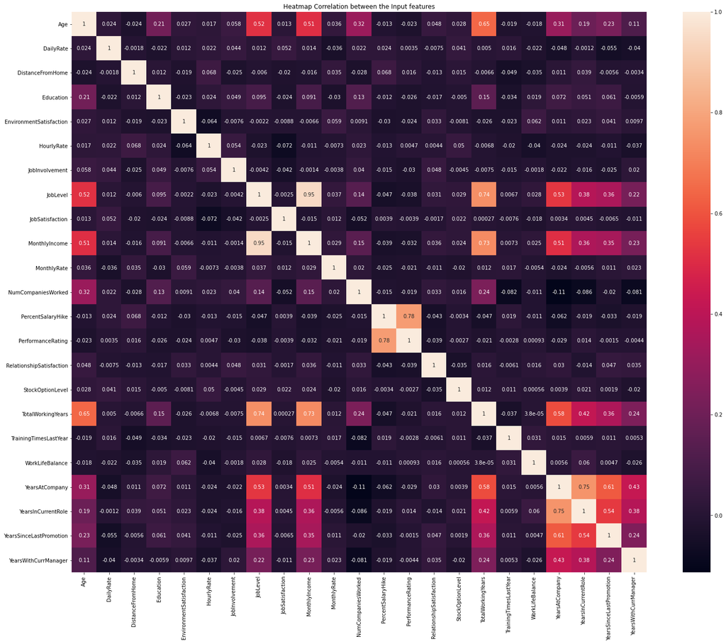

```python
plt.figure(figsize=(25,20))
sns.heatmap(df_attr.corr(), annot=True) # Correlation between the Columns to find the highly correlated columns to remove multi-collinearity
plt.title('Heatmap Correlation between the Input features')
```

The columns MonthlyIncome and JobLevel are highly co-related with 0.95 correlation. This means that the 2 columns do not add new information so one of the coulmns needs to be dropped. Dropping MonthlyIncome as the JobLevel exists and also for Income we have MonthlyRate, HourlyRate and DailyRate columns.

```python
df_attr.drop(['MonthlyIncome'],axis=1,inplace=True)
```

**3. Missing Values Imputation**

```python
# Columns with Null values

df_attr.isnull().sum()[df_attr.isnull().sum() > 0]
```

```
DistanceFromHome            2
Gender                      1
JobLevel                    1
OverTime                    1
PercentSalaryHike           1
PerformanceRating           1
RelationshipSatisfaction    1
TotalWorkingYears           2
YearsSinceLastPromotion     1
dtype: int64
```

```python
df_attr[df_attr['DistanceFromHome'].isnull()]
```

|  | Age | Attrition | BusinessTravel | DailyRate | Department | DistanceFromHome | Education | EducationField | EnvironmentSatisfaction | Gender | HourlyRate | JobInvolvement | JobLevel | JobRole | JobSatisfaction | MaritalStatus | MonthlyRate | NumCompaniesWorked | OverTime | PercentSalaryHike | PerformanceRating | RelationshipSatisfaction | StockOptionLevel | TotalWorkingYears | TrainingTimesLastYear | WorkLifeBalance | YearsAtCompany | YearsInCurrentRole | YearsSinceLastPromotion | … |
| --- | --- | --- | --- | --- | --- | --- | --- | --- | --- | --- | --- | --- | --- | --- | --- | --- | --- | --- | --- | --- | --- | --- | --- | --- | --- | --- | --- | --- | --- | --- |
| 54 | 39 | No | Travel_Rarely | 412 | Research & Development | NaN | 4 | Medical | 3 | Female | 94 | 2 | 4.0 | Manager | 2 | Divorced | 17334 | 6 | Yes | 13.0 | 3.0 | 4.0 | 2 | 21.0 | 4 | 3 | 19 | 9 | 15.0 | … |
| 104 | 38 | No | Travel_Rarely | 688 | Research & Development | NaN | 4 | Life Sciences | 4 | Male | 82 | 3 | 2.0 | Healthcare Representative | 4 | Divorced | 18899 | 9 | No | 14.0 | 3.0 | 2.0 | 1 | 10.0 | 2 | 3 | 2 | 2 | 1.0 | … |

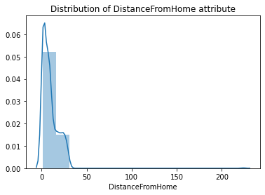

```python
sns.distplot(df_attr["DistanceFromHome"], bins=15)
plt.title('Distribution of DistanceFromHome attribute')
```

```python
df_attr['DistanceFromHome'].describe()
```

```
count    1174.000000
mean        9.495741
std        10.251379
min         1.000000
25%         2.000000
50%         7.000000
75%        14.000000
max       224.000000
Name: DistanceFromHome, dtype: float64
```

DistanceFromHome is imputed with Median as the data is Right Skewed with Mean > Median. So, Median can be imputed

```python
# Function to impute the median value

def median_imputation(df,column):
    df[column].fillna(df[column].median(), inplace=True)
```

```python
# Median value imputed in DistanceFromHome Column where there were null values

median_imputation(df_attr,'DistanceFromHome')
```

```python
df_attr[df_attr['DistanceFromHome'].isnull()]
```

|  | Age | Attrition | BusinessTravel | DailyRate | Department | DistanceFromHome | Education | EducationField | EnvironmentSatisfaction | Gender | HourlyRate | JobInvolvement | JobLevel | JobRole | JobSatisfaction | MaritalStatus | MonthlyRate | NumCompaniesWorked | OverTime | PercentSalaryHike | PerformanceRating | RelationshipSatisfaction | StockOptionLevel | TotalWorkingYears | TrainingTimesLastYear | WorkLifeBalance | YearsAtCompany | YearsInCurrentRole | YearsSinceLastPromotion | … |
| --- | --- | --- | --- | --- | --- | --- | --- | --- | --- | --- | --- | --- | --- | --- | --- | --- | --- | --- | --- | --- | --- | --- | --- | --- | --- | --- | --- | --- | --- | --- |

```python
df_attr['Gender'].value_counts()
```

```
Male      693
Female    482
Name: Gender, dtype: int64
```

```python
df_attr[df_attr['Gender'].isnull()]
```

|  | Age | Attrition | BusinessTravel | DailyRate | Department | DistanceFromHome | Education | EducationField | EnvironmentSatisfaction | Gender | HourlyRate | JobInvolvement | JobLevel | JobRole | JobSatisfaction | MaritalStatus | MonthlyRate | NumCompaniesWorked | OverTime | PercentSalaryHike | PerformanceRating | RelationshipSatisfaction | StockOptionLevel | TotalWorkingYears | TrainingTimesLastYear | WorkLifeBalance | YearsAtCompany | YearsInCurrentRole | YearsSinceLastPromotion | … |
| --- | --- | --- | --- | --- | --- | --- | --- | --- | --- | --- | --- | --- | --- | --- | --- | --- | --- | --- | --- | --- | --- | --- | --- | --- | --- | --- | --- | --- | --- | --- |
| 1061 | 56 | No | Travel_Frequently | 906 | Sales | 6.0 | 3 | Life Sciences | 3 | NaN | 86 | 4 | 4.0 | Sales Executive | 1 | Married | 18256 | 9 | No | 11.0 | 3.0 | 4.0 | 3 | 36.0 | 0 | 2 | 7 | 7 | 7.0 | … |

Gender is categorical value so using the Mode to impute for the missing value

```python
# Mode Imputation function

def mode_imputation(df,column):
    df[column].fillna(df[column].mode()[0], inplace=True)
```

```python
mode_imputation(df_attr,'Gender')
```

```python
df_attr[df_attr['Gender'].isnull()]
```

|  | Age | Attrition | BusinessTravel | DailyRate | Department | DistanceFromHome | Education | EducationField | EnvironmentSatisfaction | Gender | HourlyRate | JobInvolvement | JobLevel | JobRole | JobSatisfaction | MaritalStatus | MonthlyRate | NumCompaniesWorked | OverTime | PercentSalaryHike | PerformanceRating | RelationshipSatisfaction | StockOptionLevel | TotalWorkingYears | TrainingTimesLastYear | WorkLifeBalance | YearsAtCompany | YearsInCurrentRole | YearsSinceLastPromotion | … |
| --- | --- | --- | --- | --- | --- | --- | --- | --- | --- | --- | --- | --- | --- | --- | --- | --- | --- | --- | --- | --- | --- | --- | --- | --- | --- | --- | --- | --- | --- | --- |

```python
df_attr[df_attr['JobLevel'].isnull()]
```

|  | Age | Attrition | BusinessTravel | DailyRate | Department | DistanceFromHome | Education | EducationField | EnvironmentSatisfaction | Gender | HourlyRate | JobInvolvement | JobLevel | JobRole | JobSatisfaction | MaritalStatus | MonthlyRate | NumCompaniesWorked | OverTime | PercentSalaryHike | PerformanceRating | RelationshipSatisfaction | StockOptionLevel | TotalWorkingYears | TrainingTimesLastYear | WorkLifeBalance | YearsAtCompany | YearsInCurrentRole | YearsSinceLastPromotion | … |
| --- | --- | --- | --- | --- | --- | --- | --- | --- | --- | --- | --- | --- | --- | --- | --- | --- | --- | --- | --- | --- | --- | --- | --- | --- | --- | --- | --- | --- | --- | --- |
| 88 | 28 | No | Travel_Rarely | 1476 | Research & Development | 16.0 | 2 | Medical | 2 | Male | 68 | 4 | NaN | Healthcare Representative | 1 | Single | 4824 | 0 | No | 19.0 | 3.0 | 3.0 | 0 | 9.0 | 2 | 3 | 8 | 3 | 0.0 | … |

For the JobLevel Imputation, I am considering multiple attributes which would be used to see what value to impute for JobLevel. The attributes TotalWorkingYears, YearsAtCompany and Age are the most correlated to JobLevel so grouping by these 3 attributes and taking the mean I found the JobLevel to be around 2 for the missing value.

```python
# Grouping by YearsAtCompany, TotalWorkingYears and Age to find out the value to be imputed for JobLevel based on the mean

df_attr.groupby(['YearsAtCompany','TotalWorkingYears','Age'])['JobLevel'].mean()
```

```
YearsAtCompany  TotalWorkingYears  Age
0               0.0                18     1.0
                                   19     1.0
                                   21     1.0
                                   27     1.0
                1.0                19     1.0
                                         ...
33              34.0               55     4.0
34              34.0               52     4.0
36              37.0               55     5.0
37              38.0               58     4.0
40              40.0               58     3.0
Name: JobLevel, Length: 865, dtype: float64
```

```python
df_attr['JobLevel'].fillna(2.0, inplace=True)
```

```python
df_attr[df_attr['JobLevel'].isnull()]
```

|  | Age | Attrition | BusinessTravel | DailyRate | Department | DistanceFromHome | Education | EducationField | EnvironmentSatisfaction | Gender | HourlyRate | JobInvolvement | JobLevel | JobRole | JobSatisfaction | MaritalStatus | MonthlyRate | NumCompaniesWorked | OverTime | PercentSalaryHike | PerformanceRating | RelationshipSatisfaction | StockOptionLevel | TotalWorkingYears | TrainingTimesLastYear | WorkLifeBalance | YearsAtCompany | YearsInCurrentRole | YearsSinceLastPromotion | … |
| --- | --- | --- | --- | --- | --- | --- | --- | --- | --- | --- | --- | --- | --- | --- | --- | --- | --- | --- | --- | --- | --- | --- | --- | --- | --- | --- | --- | --- | --- | --- |

```python
df_attr[df_attr['OverTime'].isnull()]
```

|  | Age | Attrition | BusinessTravel | DailyRate | Department | DistanceFromHome | Education | EducationField | EnvironmentSatisfaction | Gender | HourlyRate | JobInvolvement | JobLevel | JobRole | JobSatisfaction | MaritalStatus | MonthlyRate | NumCompaniesWorked | OverTime | PercentSalaryHike | PerformanceRating | RelationshipSatisfaction | StockOptionLevel | TotalWorkingYears | TrainingTimesLastYear | WorkLifeBalance | YearsAtCompany | YearsInCurrentRole | YearsSinceLastPromotion | … |
| --- | --- | --- | --- | --- | --- | --- | --- | --- | --- | --- | --- | --- | --- | --- | --- | --- | --- | --- | --- | --- | --- | --- | --- | --- | --- | --- | --- | --- | --- | --- |
| 1012 | 55 | No | Travel_Rarely | 692 | Research & Development | 14.0 | 4 | Medical | 3 | Male | 61 | 4 | 5.0 | Research Director | 2 | Single | 13339 | 8 | NaN | 11.0 | 3.0 | 4.0 | 0 | 36.0 | 3 | 3 | 24 | 15 | 2.0 | … |

```python
df_attr['OverTime'].value_counts()
```

```
No     838
Yes    337
Name: OverTime, dtype: int64
```

OverTime is categorical attribute. So, using the mode to impute the OverTime based on the Mode.

```python
mode_imputation(df_attr,'OverTime')
```

```python
df_attr[df_attr['OverTime'].isnull()]
```

|  | Age | Attrition | BusinessTravel | DailyRate | Department | DistanceFromHome | Education | EducationField | EnvironmentSatisfaction | Gender | HourlyRate | JobInvolvement | JobLevel | JobRole | JobSatisfaction | MaritalStatus | MonthlyRate | NumCompaniesWorked | OverTime | PercentSalaryHike | PerformanceRating | RelationshipSatisfaction | StockOptionLevel | TotalWorkingYears | TrainingTimesLastYear | WorkLifeBalance | YearsAtCompany | YearsInCurrentRole | YearsSinceLastPromotion | … |
| --- | --- | --- | --- | --- | --- | --- | --- | --- | --- | --- | --- | --- | --- | --- | --- | --- | --- | --- | --- | --- | --- | --- | --- | --- | --- | --- | --- | --- | --- | --- |

```python
df_attr[df_attr['PercentSalaryHike'].isnull()]
```

|  | Age | Attrition | BusinessTravel | DailyRate | Department | DistanceFromHome | Education | EducationField | EnvironmentSatisfaction | Gender | HourlyRate | JobInvolvement | JobLevel | JobRole | JobSatisfaction | MaritalStatus | MonthlyRate | NumCompaniesWorked | OverTime | PercentSalaryHike | PerformanceRating | RelationshipSatisfaction | StockOptionLevel | TotalWorkingYears | TrainingTimesLastYear | WorkLifeBalance | YearsAtCompany | YearsInCurrentRole | YearsSinceLastPromotion | … |
| --- | --- | --- | --- | --- | --- | --- | --- | --- | --- | --- | --- | --- | --- | --- | --- | --- | --- | --- | --- | --- | --- | --- | --- | --- | --- | --- | --- | --- | --- | --- |
| 63 | 43 | No | Travel_Rarely | 930 | Research & Development | 6.0 | 3 | Medical | 1 | Female | 73 | 2 | 2.0 | Research Scientist | 3 | Single | 20003 | 1 | Yes | NaN | 3.0 | 1.0 | 0 | 20.0 | 3 | 1 | 20 | 7 | 1.0 | … |

PercentSalaryHike is most correlated to PerformanceRating. So, grouping by PerformanceRating to find the value for missing PercentSalaryHike. The Median and Mean is almost the same so I am choosing to impute the missing value using the median

```python
df_attr.groupby(['PerformanceRating'])['PercentSalaryHike'].median()
```

```
PerformanceRating
3.0    14.0
4.0    22.0
Name: PercentSalaryHike, dtype: float64
```

```python
df_attr.groupby(['PerformanceRating'])['PercentSalaryHike'].mean()
```

```
PerformanceRating
3.0    14.034588
4.0    21.806283
Name: PercentSalaryHike, dtype: float64
```

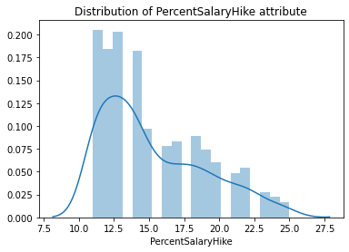

```python
sns.distplot(df_attr["PercentSalaryHike"], bins=20)
plt.title('Distribution of PercentSalaryHike attribute')
```

```python
median_imputation(df_attr,'PercentSalaryHike')
```

```python
df_attr[df_attr['PercentSalaryHike'].isnull()]
```

|  | Age | Attrition | BusinessTravel | DailyRate | Department | DistanceFromHome | Education | EducationField | EnvironmentSatisfaction | Gender | HourlyRate | JobInvolvement | JobLevel | JobRole | JobSatisfaction | MaritalStatus | MonthlyRate | NumCompaniesWorked | OverTime | PercentSalaryHike | PerformanceRating | RelationshipSatisfaction | StockOptionLevel | TotalWorkingYears | TrainingTimesLastYear | WorkLifeBalance | YearsAtCompany | YearsInCurrentRole | YearsSinceLastPromotion | … |
| --- | --- | --- | --- | --- | --- | --- | --- | --- | --- | --- | --- | --- | --- | --- | --- | --- | --- | --- | --- | --- | --- | --- | --- | --- | --- | --- | --- | --- | --- | --- |

```python
df_attr[df_attr['PerformanceRating'].isnull()]
```

|  | Age | Attrition | BusinessTravel | DailyRate | Department | DistanceFromHome | Education | EducationField | EnvironmentSatisfaction | Gender | HourlyRate | JobInvolvement | JobLevel | JobRole | JobSatisfaction | MaritalStatus | MonthlyRate | NumCompaniesWorked | OverTime | PercentSalaryHike | PerformanceRating | RelationshipSatisfaction | StockOptionLevel | TotalWorkingYears | TrainingTimesLastYear | WorkLifeBalance | YearsAtCompany | YearsInCurrentRole | YearsSinceLastPromotion | … |
| --- | --- | --- | --- | --- | --- | --- | --- | --- | --- | --- | --- | --- | --- | --- | --- | --- | --- | --- | --- | --- | --- | --- | --- | --- | --- | --- | --- | --- | --- | --- |
| 9 | 27 | Yes | Travel_Rarely | 1420 | Sales | 2.0 | 1 | Marketing | 3 | Male | 85 | 3 | 1.0 | Sales Representative | 1 | Divorced | 16346 | 0 | No | 11.0 | NaN | 2.0 | 1 | 5.0 | 3 | 3 | 4 | 3 | 0.0 | … |

PerformanceRating is correlated to PercentSalaryHike. So, using the group by to find the value of missing PerformanceRating. Using the median to impute the missing value as the mean and median are almost the same.

```python
df_attr['PercentSalaryHike'][df_attr['PerformanceRating'].isnull()]
```

```
9    11.0
Name: PercentSalaryHike, dtype: float64
```

```python
df_attr['PerformanceRating'].describe()
```

```
count    1175.000000
mean        3.162553
std         0.369115
min         3.000000
25%         3.000000
50%         3.000000
75%         3.000000
max         4.000000
Name: PerformanceRating, dtype: float64
```

```python
df_attr.groupby(['PercentSalaryHike'])['PerformanceRating'].median()
```

```
PercentSalaryHike
11.0    3.0
12.0    3.0
13.0    3.0
14.0    3.0
15.0    3.0
16.0    3.0
17.0    3.0
18.0    3.0
19.0    3.0
20.0    4.0
21.0    4.0
22.0    4.0
23.0    4.0
24.0    4.0
25.0    4.0
Name: PerformanceRating, dtype: float64
```

```python
mode_imputation(df_attr,'PerformanceRating')
```

```python
df_attr[df_attr['PerformanceRating'].isnull()]
```

|  | Age | Attrition | BusinessTravel | DailyRate | Department | DistanceFromHome | Education | EducationField | EnvironmentSatisfaction | Gender | HourlyRate | JobInvolvement | JobLevel | JobRole | JobSatisfaction | MaritalStatus | MonthlyRate | NumCompaniesWorked | OverTime | PercentSalaryHike | PerformanceRating | RelationshipSatisfaction | StockOptionLevel | TotalWorkingYears | TrainingTimesLastYear | WorkLifeBalance | YearsAtCompany | YearsInCurrentRole | YearsSinceLastPromotion | … |
| --- | --- | --- | --- | --- | --- | --- | --- | --- | --- | --- | --- | --- | --- | --- | --- | --- | --- | --- | --- | --- | --- | --- | --- | --- | --- | --- | --- | --- | --- | --- |

```python
df_attr[df_attr['RelationshipSatisfaction'].isnull()]
```

|  | Age | Attrition | BusinessTravel | DailyRate | Department | DistanceFromHome | Education | EducationField | EnvironmentSatisfaction | Gender | HourlyRate | JobInvolvement | JobLevel | JobRole | JobSatisfaction | MaritalStatus | MonthlyRate | NumCompaniesWorked | OverTime | PercentSalaryHike | PerformanceRating | RelationshipSatisfaction | StockOptionLevel | TotalWorkingYears | TrainingTimesLastYear | WorkLifeBalance | YearsAtCompany | YearsInCurrentRole | YearsSinceLastPromotion | … |
| --- | --- | --- | --- | --- | --- | --- | --- | --- | --- | --- | --- | --- | --- | --- | --- | --- | --- | --- | --- | --- | --- | --- | --- | --- | --- | --- | --- | --- | --- | --- |
| 32 | 38 | No | Non-Travel | 573 | Research & Development | 6.0 | 3 | Medical | 2 | Female | 79 | 1 | 2.0 | Research Scientist | 4 | Divorced | 15717 | 7 | Yes | 12.0 | 3.0 | NaN | 3 | 17.0 | 3 | 3 | 13 | 11 | 1.0 | … |

```python
df_attr['RelationshipSatisfaction'].unique()
```

```
array([ 3.,  2.,  1.,  4., nan])
```

Mode is used to impute the RelationshipSatisfaction as it is nomial discrete attribute with only 4 unique values.

```python
df_attr['RelationshipSatisfaction'].value_counts()
```

```
3.0    362
4.0    351
2.0    242
1.0    220
Name: RelationshipSatisfaction, dtype: int64
```

```python
mode_imputation(df_attr,'RelationshipSatisfaction')
```

```python
df_attr[df_attr['RelationshipSatisfaction'].isnull()]
```

|  | Age | Attrition | BusinessTravel | DailyRate | Department | DistanceFromHome | Education | EducationField | EnvironmentSatisfaction | Gender | HourlyRate | JobInvolvement | JobLevel | JobRole | JobSatisfaction | MaritalStatus | MonthlyRate | NumCompaniesWorked | OverTime | PercentSalaryHike | PerformanceRating | RelationshipSatisfaction | StockOptionLevel | TotalWorkingYears | TrainingTimesLastYear | WorkLifeBalance | YearsAtCompany | YearsInCurrentRole | YearsSinceLastPromotion | … |
| --- | --- | --- | --- | --- | --- | --- | --- | --- | --- | --- | --- | --- | --- | --- | --- | --- | --- | --- | --- | --- | --- | --- | --- | --- | --- | --- | --- | --- | --- | --- |

```python
df_attr[df_attr['TotalWorkingYears'].isnull()]
```

|  | Age | Attrition | BusinessTravel | DailyRate | Department | DistanceFromHome | Education | EducationField | EnvironmentSatisfaction | Gender | HourlyRate | JobInvolvement | JobLevel | JobRole | JobSatisfaction | MaritalStatus | MonthlyRate | NumCompaniesWorked | OverTime | PercentSalaryHike | PerformanceRating | RelationshipSatisfaction | StockOptionLevel | TotalWorkingYears | TrainingTimesLastYear | WorkLifeBalance | YearsAtCompany | YearsInCurrentRole | YearsSinceLastPromotion | … |
| --- | --- | --- | --- | --- | --- | --- | --- | --- | --- | --- | --- | --- | --- | --- | --- | --- | --- | --- | --- | --- | --- | --- | --- | --- | --- | --- | --- | --- | --- | --- |
| 82 | 38 | No | Travel_Rarely | 362 | Research & Development | 1.0 | 1 | Life Sciences | 3 | Female | 43 | 3 | 1.0 | Research Scientist | 1 | Single | 14561 | 3 | No | 17.0 | 3.0 | 4.0 | 0 | NaN | 3 | 2 | 0 | 0 | 0.0 | … |
| 968 | 39 | Yes | Travel_Frequently | 203 | Research & Development | 2.0 | 3 | Life Sciences | 1 | Male | 84 | 3 | 4.0 | Healthcare Representative | 4 | Divorced | 13547 | 7 | No | 11.0 | 3.0 | 4.0 | 3 | NaN | 4 | 3 | 18 | 7 | 11.0 | … |

TotalWorkingYears is most correlated to JobLevel. So, getting the values for TotalWorkingYears from the JobLevel based values. Using the Median value of TotalWorkingYears for each joblevel to fill the missing values in TotalWorkingYears

```python
df_attr['JobLevel'][df_attr['TotalWorkingYears'].isnull()]
```

```
82     1.0
968    4.0
Name: JobLevel, dtype: float64
```

```python
df_attr.groupby(['JobLevel'])['TotalWorkingYears'].median()
```

```
JobLevel
1.0     6.0
2.0    10.0
3.0    14.0
4.0    26.0
5.0    24.0
Name: TotalWorkingYears, dtype: float64
```

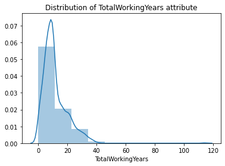

```python
sns.distplot(df_attr["TotalWorkingYears"], bins=10)
plt.title('Distribution of TotalWorkingYears attribute')
```

```python
df_attr['TotalWorkingYears'].iloc[82] = 6.0
```

```python
df_attr['TotalWorkingYears'].iloc[968] = 26.0
```

```python
df_attr[df_attr['TotalWorkingYears'].isnull()]
```

|  | Age | Attrition | BusinessTravel | DailyRate | Department | DistanceFromHome | Education | EducationField | EnvironmentSatisfaction | Gender | HourlyRate | JobInvolvement | JobLevel | JobRole | JobSatisfaction | MaritalStatus | MonthlyRate | NumCompaniesWorked | OverTime | PercentSalaryHike | PerformanceRating | RelationshipSatisfaction | StockOptionLevel | TotalWorkingYears | TrainingTimesLastYear | WorkLifeBalance | YearsAtCompany | YearsInCurrentRole | YearsSinceLastPromotion | … |
| --- | --- | --- | --- | --- | --- | --- | --- | --- | --- | --- | --- | --- | --- | --- | --- | --- | --- | --- | --- | --- | --- | --- | --- | --- | --- | --- | --- | --- | --- | --- |

```python
df_attr[df_attr['YearsSinceLastPromotion'].isnull()]
```

|  | Age | Attrition | BusinessTravel | DailyRate | Department | DistanceFromHome | Education | EducationField | EnvironmentSatisfaction | Gender | HourlyRate | JobInvolvement | JobLevel | JobRole | JobSatisfaction | MaritalStatus | MonthlyRate | NumCompaniesWorked | OverTime | PercentSalaryHike | PerformanceRating | RelationshipSatisfaction | StockOptionLevel | TotalWorkingYears | TrainingTimesLastYear | WorkLifeBalance | YearsAtCompany | YearsInCurrentRole | YearsSinceLastPromotion | … |
| --- | --- | --- | --- | --- | --- | --- | --- | --- | --- | --- | --- | --- | --- | --- | --- | --- | --- | --- | --- | --- | --- | --- | --- | --- | --- | --- | --- | --- | --- | --- |
| 993 | 36 | No | Non-Travel | 301 | Sales | 15.0 | 4 | Marketing | 4 | Male | 88 | 1 | 2.0 | Sales Executive | 4 | Divorced | 10436 | 1 | No | 24.0 | 4.0 | 1.0 | 1 | 15.0 | 4 | 2 | 15 | 12 | NaN | … |

```python
df_attr['YearsSinceLastPromotion'].describe()
```

```
count    1175.000000
mean        2.125106
std         3.183567
min         0.000000
25%         0.000000
50%         1.000000
75%         2.000000
max        15.000000
Name: YearsSinceLastPromotion, dtype: float64
```

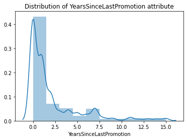

```python
sns.distplot(df_attr["YearsSinceLastPromotion"], bins=10)
plt.title('Distribution of YearsSinceLastPromotion attribute')
```

Imputing Median for the YearsSinceLastPromotion as the data is skewed with Mean > Median. So, safely median can be imputed

```python
median_imputation(df_attr,'YearsSinceLastPromotion')
```

```python
df_attr[df_attr['YearsSinceLastPromotion'].isnull()]
```

|  | Age | Attrition | BusinessTravel | DailyRate | Department | DistanceFromHome | Education | EducationField | EnvironmentSatisfaction | Gender | HourlyRate | JobInvolvement | JobLevel | JobRole | JobSatisfaction | MaritalStatus | MonthlyRate | NumCompaniesWorked | OverTime | PercentSalaryHike | PerformanceRating | RelationshipSatisfaction | StockOptionLevel | TotalWorkingYears | TrainingTimesLastYear | WorkLifeBalance | YearsAtCompany | YearsInCurrentRole | YearsSinceLastPromotion | … |
| --- | --- | --- | --- | --- | --- | --- | --- | --- | --- | --- | --- | --- | --- | --- | --- | --- | --- | --- | --- | --- | --- | --- | --- | --- | --- | --- | --- | --- | --- | --- |

```python
# Checking if all the missing values are handled and there are no missing values

df_attr.isnull().sum()[df_attr.isnull().sum() > 0]
```

```
Series([], dtype: int64)
```

**4. Outlier Detection and Handling**

TotalWorkingYears is definitely a outlier as 114 years is not possible for a normal person to live also.

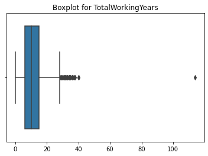

```python
sns.boxplot(df_attr[['TotalWorkingYears']])
plt.title('Boxplot for TotalWorkingYears')
```

```python
df_attr['TotalWorkingYears'][df_attr['TotalWorkingYears'] > 40].sort_values(ascending=False)
```

```
143    114.0
Name: TotalWorkingYears, dtype: float64
```

```python
df_attr[df_attr['TotalWorkingYears'] == 114]
```

|  | Age | Attrition | BusinessTravel | DailyRate | Department | DistanceFromHome | Education | EducationField | EnvironmentSatisfaction | Gender | HourlyRate | JobInvolvement | JobLevel | JobRole | JobSatisfaction | MaritalStatus | MonthlyRate | NumCompaniesWorked | OverTime | PercentSalaryHike | PerformanceRating | RelationshipSatisfaction | StockOptionLevel | TotalWorkingYears | TrainingTimesLastYear | WorkLifeBalance | YearsAtCompany | YearsInCurrentRole | YearsSinceLastPromotion | … |
| --- | --- | --- | --- | --- | --- | --- | --- | --- | --- | --- | --- | --- | --- | --- | --- | --- | --- | --- | --- | --- | --- | --- | --- | --- | --- | --- | --- | --- | --- | --- |
| 143 | 36 | No | Travel_Frequently | 541 | Sales | 3.0 | 4 | Medical | 1 | Male | 48 | 2 | 3.0 | Sales Executive | 4 | Married | 7246 | 4 | No | 11.0 | 3.0 | 1.0 | 1 | 114.0 | 2 | 3 | 13 | 9 | 1.0 | … |

```python
# Grouping by Age, Education, EducationField and YearsAtCompany to find the TotalWorkingYears for an average person with attribute
# values for all the other attributes mentioned

df_attr.groupby(['Age','Education','EducationField','YearsAtCompany'])['TotalWorkingYears'].mean()
```

```
Age  Education  EducationField   YearsAtCompany
18   1          Medical          0                  0.0
     2          Medical          0                  0.0
     3          Life Sciences    0                  0.0
                Marketing        0                  0.0
                Medical          0                  0.0
                                                   ...
59   4          Human Resources  3                 30.0
                Medical          9                 25.0
60   3          Life Sciences    29                33.0
                Marketing        18                22.0
     4          Marketing        2                 10.0
Name: TotalWorkingYears, Length: 1037, dtype: float64
```

```python
rowindex = df_attr[df_attr['TotalWorkingYears'] == 114].index # FInding the index of the TotalWorkingYears attribute where the value is 114
```

```python
df_attr.loc[rowindex,'TotalWorkingYears'] = 16.0 # Replacing the value with 16.0 for the outlier based on the mean find out by group by statement above
```

```python
df_attr.loc[rowindex,'TotalWorkingYears']
```

```
143    16.0
Name: TotalWorkingYears, dtype: float64
```

```python
df_attr['TotalWorkingYears'].describe()
```

```
count    1176.000000
mean       11.327381
std         7.821681
min         0.000000
25%         6.000000
50%        10.000000
75%        15.000000
max        40.000000
Name: TotalWorkingYears, dtype: float64
```

YearsWithCurrManager is 219 which is not possible practically. So, need to change the value in order to suppress the outlier

```python
df_attr['YearsWithCurrManager'].unique()
```

```
array([  2,   4,   3,   0,  17,  12,  10,   9,   1,   7,   8,   6,  13,
        16,   5,  11,  15,  14, 219], dtype=int64)
```

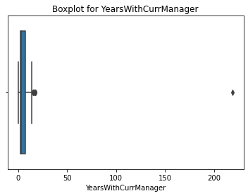

```python
sns.boxplot(df_attr["YearsWithCurrManager"])
plt.title('Boxplot for YearsWithCurrManager')
```

```python
df_attr[df_attr['YearsWithCurrManager'] == 219]
```

|  | Age | Attrition | BusinessTravel | DailyRate | Department | DistanceFromHome | Education | EducationField | EnvironmentSatisfaction | Gender | HourlyRate | JobInvolvement | JobLevel | JobRole | JobSatisfaction | MaritalStatus | MonthlyRate | NumCompaniesWorked | OverTime | PercentSalaryHike | PerformanceRating | RelationshipSatisfaction | StockOptionLevel | TotalWorkingYears | TrainingTimesLastYear | WorkLifeBalance | YearsAtCompany | YearsInCurrentRole | YearsSinceLastPromotion | … |
| --- | --- | --- | --- | --- | --- | --- | --- | --- | --- | --- | --- | --- | --- | --- | --- | --- | --- | --- | --- | --- | --- | --- | --- | --- | --- | --- | --- | --- | --- | --- |
| 1054 | 42 | No | Non-Travel | 495 | Research & Development | 2.0 | 1 | Life Sciences | 3 | Male | 37 | 3 | 4.0 | Manager | 3 | Married | 26582 | 0 | Yes | 13.0 | 3.0 | 4.0 | 0 | 21.0 | 3 | 2 | 20 | 8 | 2.0 | … |

```python
df_attr.groupby(['Age','TotalWorkingYears','YearsAtCompany'])['YearsWithCurrManager'].mean()
```

```
Age  TotalWorkingYears  YearsAtCompany
18   0.0                0                  0.000000
19   0.0                0                  0.000000
     1.0                0                  0.000000
                        1                  0.200000
20   1.0                1                  0.333333
                                            ...
59   30.0               3                  2.000000
                        5                  3.000000
60   10.0               2                  2.000000
     22.0               18                11.000000
     33.0               29                10.000000
Name: YearsWithCurrManager, Length: 866, dtype: float64
```

The YearsWithCurrManager for a average person with Age=42, TotalWorkingYears=21 and YearsAtCompany=20 is 8. So, by the above groupby command I found the value to be 8 to change the YearsWithCurrManager to handle the outlier

```python
rowindex_1 = df_attr[df_attr['YearsWithCurrManager'] == 219].index # Index of the row where YearsWithCurrManager is 219
```

```python
df_attr.loc[rowindex_1,'YearsWithCurrManager'] = 8.0 # Replace the outlier 219 with 8 for YearsWithCurrManager
```

```python
df_attr.loc[rowindex_1,'YearsWithCurrManager']
```

```
1054    8.0
Name: YearsWithCurrManager, dtype: float64
```

```python
df_attr['YearsWithCurrManager'].describe()
```

```
count    1176.000000
mean        4.062925
std         3.566194
min         0.000000
25%         2.000000
50%         3.000000
75%         7.000000
max        17.000000
Name: YearsWithCurrManager, dtype: float64
```

DistanceFromHome of 224 indicates that the person lives very far which might be outlier and could be a data entry mistake writing 224 instead of 24

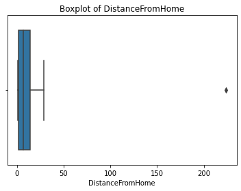

```python
sns.boxplot(df_attr['DistanceFromHome'])
plt.title('Boxplot of DistanceFromHome')
```

```python
df_attr[df_attr['DistanceFromHome'] > 30]
```

|  | Age | Attrition | BusinessTravel | DailyRate | Department | DistanceFromHome | Education | EducationField | EnvironmentSatisfaction | Gender | HourlyRate | JobInvolvement | JobLevel | JobRole | JobSatisfaction | MaritalStatus | MonthlyRate | NumCompaniesWorked | OverTime | PercentSalaryHike | PerformanceRating | RelationshipSatisfaction | StockOptionLevel | TotalWorkingYears | TrainingTimesLastYear | WorkLifeBalance | YearsAtCompany | YearsInCurrentRole | YearsSinceLastPromotion | … |
| --- | --- | --- | --- | --- | --- | --- | --- | --- | --- | --- | --- | --- | --- | --- | --- | --- | --- | --- | --- | --- | --- | --- | --- | --- | --- | --- | --- | --- | --- | --- |
| 126 | 31 | No | Travel_Rarely | 1062 | Research & Development | 224.0 | 3 | Medical | 3 | Female | 96 | 2 | 2.0 | Healthcare Representative | 1 | Single | 17198 | 1 | No | 19.0 | 3.0 | 2.0 | 0 | 10.0 | 2 | 3 | 10 | 9 | 1.0 | … |

```python
rowindex_2 = df_attr[df_attr['DistanceFromHome'] == 224].index # Index where the value of DistanceFromHome is 224
```

```python
df_attr.loc[rowindex_2,'DistanceFromHome'] = 24.0 # Changing the value to 24 for DistanceFromHome
```

```python
df_attr.loc[rowindex_2,'DistanceFromHome']
```

```
126    24.0
Name: DistanceFromHome, dtype: float64
```

```python
df_attr['DistanceFromHome'].describe()
```

```
count    1176.000000
mean        9.321429
std         8.118615
min         1.000000
25%         2.000000
50%         7.000000
75%        14.000000
max        29.000000
Name: DistanceFromHome, dtype: float64
```

```python
df_attr.describe()
```

|  | Age | DailyRate | DistanceFromHome | Education | EnvironmentSatisfaction | HourlyRate | JobInvolvement | JobLevel | JobSatisfaction | MonthlyRate | NumCompaniesWorked | PercentSalaryHike | PerformanceRating | RelationshipSatisfaction | StockOptionLevel | TotalWorkingYears | TrainingTimesLastYear | WorkLifeBalance | YearsAtCompany | YearsInCurrentRole | YearsSinceLastPromotion | YearsWithCurrManager |
| --- | --- | --- | --- | --- | --- | --- | --- | --- | --- | --- | --- | --- | --- | --- | --- | --- | --- | --- | --- | --- | --- | --- |
| count | 1176.000000 | 1176.000000 | 1176.000000 | 1176.000000 | 1176.000000 | 1176.000000 | 1176.000000 | 1176.000000 | 1176.000000 | 1176.000000 | 1176.000000 | 1176.000000 | 1176.000000 | 1176.000000 | 1176.000000 | 1176.000000 | 1176.000000 | 1176.000000 | 1176.000000 | 1176.000000 | 1176.000000 | 1176.000000 |
| mean | 36.960034 | 800.386905 | 9.321429 | 2.895408 | 2.704932 | 65.822279 | 2.740646 | 2.068878 | 2.710034 | 14467.688776 | 2.709184 | 15.294218 | 3.162415 | 2.718537 | 0.795918 | 11.327381 | 2.809524 | 2.747449 | 6.918367 | 4.151361 | 2.124150 | 4.062925 |
| std | 9.071964 | 404.709216 | 8.118615 | 1.025685 | 1.094128 | 20.292035 | 0.719277 | 1.109119 | 1.113217 | 7107.658362 | 2.476191 | 3.697521 | 0.368988 | 1.083664 | 0.847033 | 7.821681 | 1.307697 | 0.691586 | 6.107140 | 3.501618 | 3.182382 | 3.566194 |
| min | 18.000000 | 102.000000 | 1.000000 | 1.000000 | 1.000000 | 30.000000 | 1.000000 | 1.000000 | 1.000000 | 2094.000000 | 0.000000 | 11.000000 | 3.000000 | 1.000000 | 0.000000 | 0.000000 | 0.000000 | 1.000000 | 0.000000 | 0.000000 | 0.000000 | 0.000000 |
| 25% | 30.000000 | 461.750000 | 2.000000 | 2.000000 | 2.000000 | 48.000000 | 2.000000 | 1.000000 | 2.000000 | 8275.000000 | 1.000000 | 12.000000 | 3.000000 | 2.000000 | 0.000000 | 6.000000 | 2.000000 | 2.000000 | 3.000000 | 2.000000 | 0.000000 | 2.000000 |
| 50% | 36.000000 | 796.000000 | 7.000000 | 3.000000 | 3.000000 | 66.000000 | 3.000000 | 2.000000 | 3.000000 | 14488.000000 | 2.000000 | 14.000000 | 3.000000 | 3.000000 | 1.000000 | 10.000000 | 3.000000 | 3.000000 | 5.000000 | 3.000000 | 1.000000 | 3.000000 |
| 75% | 43.000000 | 1162.000000 | 14.000000 | 4.000000 | 4.000000 | 83.000000 | 3.000000 | 3.000000 | 4.000000 | 20627.250000 | 4.000000 | 18.000000 | 3.000000 | 4.000000 | 1.000000 | 15.000000 | 3.000000 | 3.000000 | 9.000000 | 7.000000 | 2.000000 | 7.000000 |
| max | 60.000000 | 1499.000000 | 29.000000 | 5.000000 | 4.000000 | 100.000000 | 4.000000 | 5.000000 | 4.000000 | 26999.000000 | 9.000000 | 25.000000 | 4.000000 | 4.000000 | 3.000000 | 40.000000 | 6.000000 | 4.000000 | 40.000000 | 18.000000 | 15.000000 | 17.000000 |

**All the data cleaning steps are completed by making the data without outliers, no missing values or multi collinearity between the individual attributes.**

```python
#df_attr.to_csv('employee_attrition_clean.csv')
```

```python
# df_attr = pd.read_csv('employee_attrition_clean.csv')
```

```python
df_attr.info()
```

```
<class 'pandas.core.frame.DataFrame'>
RangeIndex: 1176 entries, 0 to 1175
Data columns (total 30 columns):
 #   Column                    Non-Null Count  Dtype
---  ------                    --------------  -----
 0   Age                       1176 non-null   int64
 1   Attrition                 1176 non-null   object
 2   BusinessTravel            1176 non-null   object
 3   DailyRate                 1176 non-null   int64
 4   Department                1176 non-null   object
 5   DistanceFromHome          1176 non-null   float64
 6   Education                 1176 non-null   int64
 7   EducationField            1176 non-null   object
 8   EnvironmentSatisfaction   1176 non-null   int64
 9   Gender                    1176 non-null   object
```

[output cut: 22 more lines]

```python
df_attr.skew()
```

```
Age                         0.392500
DailyRate                   0.005734
DistanceFromHome            0.948888
Education                  -0.268450
EnvironmentSatisfaction    -0.305683
HourlyRate                 -0.004153
JobInvolvement             -0.489122
JobLevel                    1.033446
JobSatisfaction            -0.314945
MonthlyRate                -0.003637
NumCompaniesWorked          0.999721
PercentSalaryHike           0.772706
PerformanceRating           1.832906
RelationshipSatisfaction   -0.307932
StockOptionLevel            0.956905
TotalWorkingYears           1.138049
TrainingTimesLastYear       0.524685
WorkLifeBalance            -0.624377
YearsAtCompany              1.824956
YearsInCurrentRole          0.891223
YearsSinceLastPromotion     2.077200
YearsWithCurrManager        0.914221
dtype: float64
```

# Discretization of Column Values for Association Rule Mining Algorithm

For Association Rule Mining, we need all the attributes to be categorical. So, converting all the continous numerical attribtes to discrete values using discretization using qcut and cut methods in the python

```python
df_attr.select_dtypes(include=np.number).columns # All the columns with Numerical Attributes
```

```
Index(['Age', 'DailyRate', 'DistanceFromHome', 'Education',
       'EnvironmentSatisfaction', 'HourlyRate', 'JobInvolvement', 'JobLevel',
       'JobSatisfaction', 'MonthlyRate', 'NumCompaniesWorked',
       'PercentSalaryHike', 'PerformanceRating', 'RelationshipSatisfaction',
       'StockOptionLevel', 'TotalWorkingYears', 'TrainingTimesLastYear',
       'WorkLifeBalance', 'YearsAtCompany', 'YearsInCurrentRole',
       'YearsSinceLastPromotion', 'YearsWithCurrManager'],
      dtype='object')
```

```python
# Labels to be used for creating the discrete values for the continuous valued columns

labels = ['Low', 'Medium', 'High', 'Very High']
```

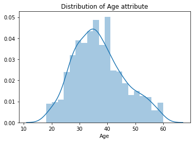

```python
sns.distplot(df_attr["Age"], bins=20)
plt.title('Distribution of Age attribute')
```

```python
df_attr['Age'].describe()
```

```
count    1176.000000
mean       36.960034
std         9.071964
min        18.000000
25%        30.000000
50%        36.000000
75%        43.000000
max        60.000000
Name: Age, dtype: float64
```

```python
# Discretizing Age Column values into 4 age groups

df_attr['Age'] = pd.cut(df_attr['Age'], bins = [17,23,40,55,65], labels = ['Young Adult','Adult','Elderly','Senior Citizen'])
```

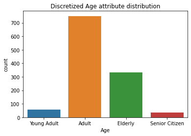

```python
sns.countplot(df_attr['Age'])
plt.title('Discretized Age attribute distribution')
```

```python
df_attr['Age'].value_counts()
```

```
Adult             750
Elderly           333
Young Adult        56
Senior Citizen     37
Name: Age, dtype: int64
```

```python
df_attr[['Age']].info()
```

```
<class 'pandas.core.frame.DataFrame'>
RangeIndex: 1176 entries, 0 to 1175
Data columns (total 1 columns):
 #   Column  Non-Null Count  Dtype
---  ------  --------------  -----
 0   Age     1176 non-null   category
dtypes: category(1)
memory usage: 1.5 KB
```

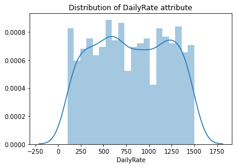

```python
sns.distplot(df_attr["DailyRate"], bins=20)
plt.title('Distribution of DailyRate attribute')
```

```python
# Discretizing the DailyRate Column attribute into 4 categories using qcut

df_attr['DailyRate'] = pd.qcut(df_attr['DailyRate'], q=4, labels = labels)
```

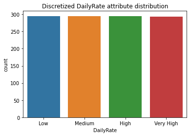

```python
sns.countplot(df_attr['DailyRate'])
plt.title('Discretized DailyRate attribute distribution')
```

```python
df_attr[['DailyRate']].info()
```

```
<class 'pandas.core.frame.DataFrame'>
RangeIndex: 1176 entries, 0 to 1175
Data columns (total 1 columns):
 #   Column     Non-Null Count  Dtype
---  ------     --------------  -----
 0   DailyRate  1176 non-null   category
dtypes: category(1)
memory usage: 1.5 KB
```

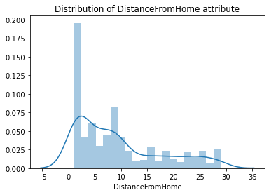

```python
sns.distplot(df_attr["DistanceFromHome"], bins=20)
plt.title('Distribution of DistanceFromHome attribute')
```

```python
df_attr['DistanceFromHome'] = pd.qcut(df_attr['DistanceFromHome'], q=4, labels = labels)
```

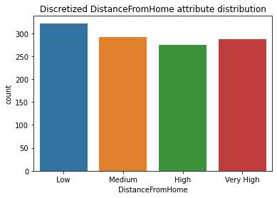

```python
sns.countplot(df_attr['DistanceFromHome'])
plt.title('Discretized DistanceFromHome attribute distribution')
```

```python
df_attr["Education"].unique()
```

```
array([1, 4, 2, 3, 5], dtype=int64)
```

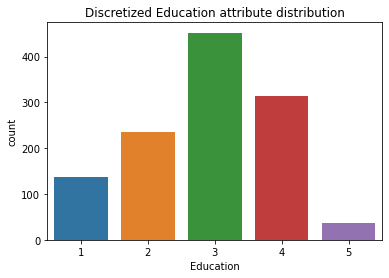

```python
sns.countplot(df_attr['Education']) # Values are already discrete and not continuous to require discretization
plt.title('Discretized Education attribute distribution')
```

```python
df_attr['EnvironmentSatisfaction'].unique()
```

```
array([4, 3, 1, 2], dtype=int64)
```

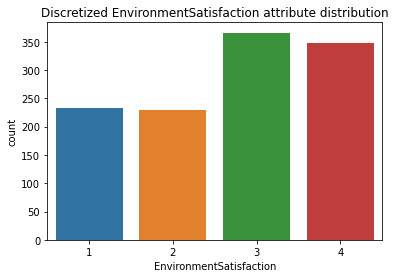

```python
sns.countplot(df_attr['EnvironmentSatisfaction'])
plt.title('Discretized EnvironmentSatisfaction attribute distribution')
```

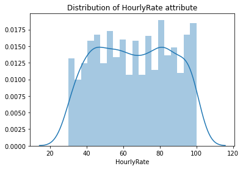

```python
sns.distplot(df_attr['HourlyRate'], bins = 20)
plt.title('Distribution of HourlyRate attribute')
```

**Discretizing the HourlyRate into 4 discrete bins as defined below**

```python
df_attr['HourlyRate'] = pd.cut(df_attr['HourlyRate'], bins = [25,45,60,80,110], labels = labels)
```

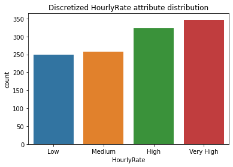

```python
sns.countplot(df_attr['HourlyRate'])
plt.title('Discretized HourlyRate attribute distribution')
```

```python
df_attr['JobInvolvement'].unique()
```

```
array([3, 2, 4, 1], dtype=int64)
```

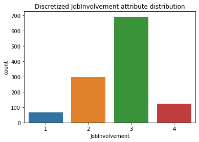

```python
sns.countplot(df_attr['JobInvolvement'])
plt.title('Discretized JobInvolvement attribute distribution')
```

```python
df_attr['JobLevel'].unique()
```

```
array([2., 4., 3., 1., 5.])
```

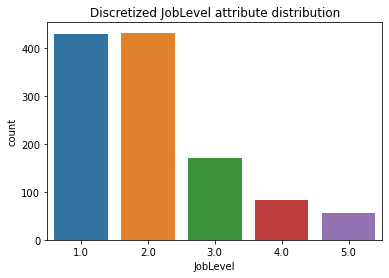

```python
sns.countplot(df_attr['JobLevel'])
plt.title('Discretized JobLevel attribute distribution')
```

```python
df_attr['JobRole'].unique()
```

```
array(['Sales Executive', 'Laboratory Technician',
       'Healthcare Representative', 'Manager', 'Manufacturing Director',
       'Sales Representative', 'Human Resources', 'Research Scientist',
       'Research Director'], dtype=object)
```

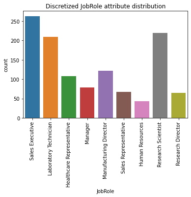

```python
new_graph = sns.countplot(df_attr['JobRole'])

new_graph.set_xticklabels(labels = df_attr['JobRole'].unique(), rotation=90)

plt.title('Discretized JobRole attribute distribution')
```

```python
df_attr['JobSatisfaction'].unique()
```

```
array([3, 2, 4, 1], dtype=int64)
```

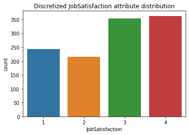

```python
sns.countplot(df_attr['JobSatisfaction'])
plt.title('Discretized JobSatisfaction attribute distribution')
```

```python
df_attr['MaritalStatus'].unique()
```

```
array(['Married', 'Single', 'Divorced'], dtype=object)
```

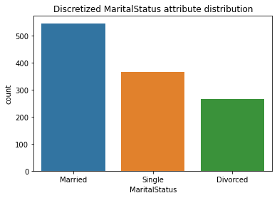

```python
sns.countplot(df_attr['MaritalStatus'])
plt.title('Discretized MaritalStatus attribute distribution')
```

```python
df_attr['MonthlyRate'].unique()
```

```
array([ 2939, 21821,  7824, ..., 18725, 16379, 22422], dtype=int64)
```

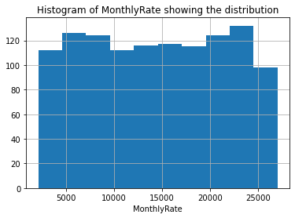

```python
df_attr['MonthlyRate'].hist()
plt.title('Histogram of MonthlyRate showing the distribution')
plt.xlabel('MonthlyRate')
```

```python
df_attr['MonthlyRate'] = pd.qcut(df_attr['MonthlyRate'], q=4, labels = labels)
```

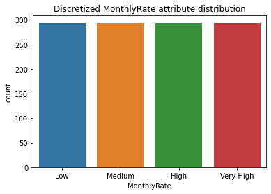

```python
sns.countplot(df_attr['MonthlyRate'])
plt.title('Discretized MonthlyRate attribute distribution')
```

```python
df_attr['NumCompaniesWorked'].unique()
```

```
array([8, 7, 1, 2, 9, 0, 4, 6, 3, 5], dtype=int64)
```

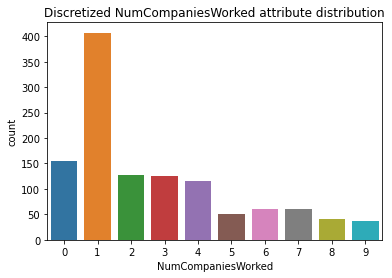

```python
sns.countplot(df_attr['NumCompaniesWorked'])
plt.title('Discretized NumCompaniesWorked attribute distribution')
```

```python
df_attr['OverTime'].unique()
```

```
array(['No', 'Yes'], dtype=object)
```

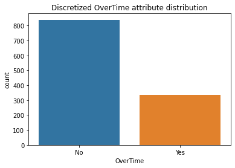

```python
sns.countplot(df_attr['OverTime'])
plt.title('Discretized OverTime attribute distribution')
```

```python
df_attr['PercentSalaryHike'].unique()
```

```
array([15., 20., 17., 19., 14., 13., 11., 12., 24., 18., 16., 23., 22.,
       21., 25.])
```

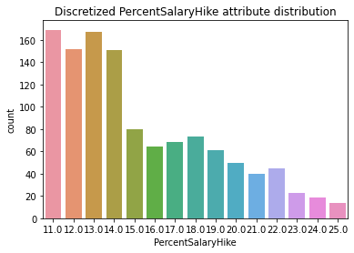

```python
sns.countplot(df_attr['PercentSalaryHike'])
plt.title('Discretized PercentSalaryHike attribute distribution')
```

```python
df_attr['PerformanceRating'].unique()
```

```
array([3., 4.])
```